# Hackaton

Danil Tukanov, Sergei Vladimirov, Anna Kalinina

2025-11-02

# Факторы, ассоциированные с наличием медицинской страховки: вторичный анализ национального исследования

1. ВВЕДЕНИЕ

Обеспечение доступа к качественному медицинскому обслуживанию – одна из важнейших задач современного общества. В странах с рыночно-ориентированной системой здравоохранения, таких как США, наличие медицинской страховки (МС) является критическим фактором, снижающим финансовые барьеры на пути получения необходимой медицинской помощи. Несмотря на это, значительная часть населения остается без страхового покрытия, что порождает серьезные проблемы в сфере общественного здоровья и социального неравенства. В связи с этим идентификация факторов, определяющих вероятность обладания медицинской страховкой, приобретает высокую актуальность для формирования целенаправленной и эффективной социальной политики.

Целью данного исследования является выявление факторов, ассоциированных с наличием у респондентов медицинской страховки. Используя данные кросс-секционного опроса, мы проанализируем, как демографические и социально-экономические характеристики связаны с вероятностью иметь страховое покрытие.

2. МЕТОДЫ

2.1 Дизайн исследования и источник данных

Мы провели вторичное кросс-секционное исследование. Анализ выполнялся на основе данных Обзора медицинских расходов (Medical Expenditure Panel Survey) за 1996 год. Датасет содержит информацию о респондентах, включая бинарную переменную insurance (наличие медицинской страховки), а также ряд независимых признаков.

2.2 Переменные исследования

Зависимая переменная:

insurance — наличие медицинской страховки (бинарная: да/нет).

Независимые переменные:

Демографические: age (возраст, лет), gender (пол), ethnicity (этническая группа), married (состоит в браке).

Социально-экономические: education (уровень образования), selfemp (статус самозанятого), region (регион проживания), family (количество членов семьи).

Характеристики здоровья: health (самооценка здоровья как “здоров”), limit (наличие ограничений в деятельности).

2.3. Методы статистического анализа

На первом этапе исследования была получена общая характеристика выборки с помощью описательной статистики. Для категориальных переменных рассчитывались абсолютные и относительные частоты (проценты), а для количественных показателей - средние значения со стандартными отклонениями. Все расчеты были стратифицированы по статусу наличия медицинской страховки.

На этапе однофакторного анализа для оценки статистической значимости связей между категориальными переменными и наличием страховки использовался критерий хи-квадрат Пирсона с поправкой Йейтса. Статистически значимыми считались различия при достижении уровня значимости p < 0,05. Сила выявленных ассоциаций количественно оценивалась через расчет отношений рисков (RR) с построением 95% доверительных интервалов.

Статистический анализ проводился с использованием программной среды R версии 4.3.1.

2.4. Этика

Исследование выполнено на вторичных обезличенных данных, в связи с чем одобрение этического комитета не требовалось.

# Струкутура данных

```
##     rownames       health               age           limit
##  Min.   :   1   Length:8802        Min.   :18.00   Length:8802
##  1st Qu.:2201   Class :character   1st Qu.:30.00   Class :character
##  Median :4402   Mode  :character   Median :39.00   Mode  :character
##  Mean   :4402                      Mean   :38.94
##  3rd Qu.:6602                      3rd Qu.:48.00
##  Max.   :8802                      Max.   :62.00
##     gender           insurance           married            selfemp
##  Length:8802        Length:8802        Length:8802        Length:8802
##  Class :character   Class :character   Class :character   Class :character
##  Mode  :character   Mode  :character   Mode  :character   Mode  :character
##
##
##
##      family          region           ethnicity          education
##  Min.   : 1.000   Length:8802        Length:8802        Length:8802
##  1st Qu.: 2.000   Class :character   Class :character   Class :character
##  Median : 3.000   Mode  :character   Mode  :character   Mode  :character
##  Mean   : 3.094
##  3rd Qu.: 4.000
##  Max.   :14.000
```

# Описание данных

Сформировать таблицы с базовыми описательными статистиками.

## Черновик таблицы 1

| **Характеристика** | Описательные характеристики респондентов **Всего** N = 8802<sup>1</sup> | Описательные характеристики респондентов **Нет страховки** N = 1750<sup>1</sup> | Описательные характеристики респондентов **Есть страховка** N = 7052<sup>1</sup> |
| --- | --- | --- | --- |
| Возраст,лет | 39 (11) | 36 (11) | 40 (11) |
| Пол |  |  |  |
| Женский | 4,169 (47%) | 715 (41%) | 3,454 (49%) |
| Мужской | 4,633 (53%) | 1,035 (59%) | 3,598 (51%) |
| Этническая группа |  |  |  |
| Афроамериканцы | 1,083 (12%) | 259 (15%) | 824 (12%) |
| Европеоидные | 7,354 (84%) | 1,401 (80%) | 5,953 (84%) |
| Другие | 365 (4.1%) | 90 (5.1%) | 275 (3.9%) |
| Регион |  |  |  |
| Средний Запад | 2,023 (23%) | 296 (17%) | 1,727 (24%) |
| Северо-восток | 1,682 (19%) | 283 (16%) | 1,399 (20%) |
| Юг | 3,075 (35%) | 673 (38%) | 2,402 (34%) |
| Запад | 2,022 (23%) | 498 (28%) | 1,524 (22%) |
| Состоит в браке | 5,433 (62%) | 774 (44%) | 4,659 (66%) |
| Количество членов семьи | 3.09 (1.56) | 3.33 (1.92) | 3.03 (1.45) |
| Здоров по самоотчету | 8,173 (93%) | 1,579 (90%) | 6,594 (94%) |
| Есть ограничения | 1,231 (14%) | 231 (13%) | 1,000 (14%) |
| Уровень образования |  |  |  |
| Нет диплома | 1,119 (13%) | 518 (30%) | 601 (8.5%) |
| Аттестат (GED) | 374 (4.2%) | 109 (6.2%) | 265 (3.8%) |
| Средняя школа | 4,434 (50%) | 828 (47%) | 3,606 (51%) |
| Бакалавр | 1,549 (18%) | 167 (9.5%) | 1,382 (20%) |
| Магистр | 524 (6.0%) | 33 (1.9%) | 491 (7.0%) |
| Доктор наук (PhD) | 135 (1.5%) | 8 (0.5%) | 127 (1.8%) |
| Другое | 667 (7.6%) | 87 (5.0%) | 580 (8.2%) |
| Самозанятый | 1,071 (12%) | 333 (19%) | 738 (10%) |

<sup>1</sup> Mean (SD); n (%)

# Визуализация данных

Визуализировать распределения значений признаков средствами ggplot2 и сопутствующих пакетов. Подобрать и реализовать средства для визуальной оценки взаимосвязи между наличием МС и собранными признаками пациентов.

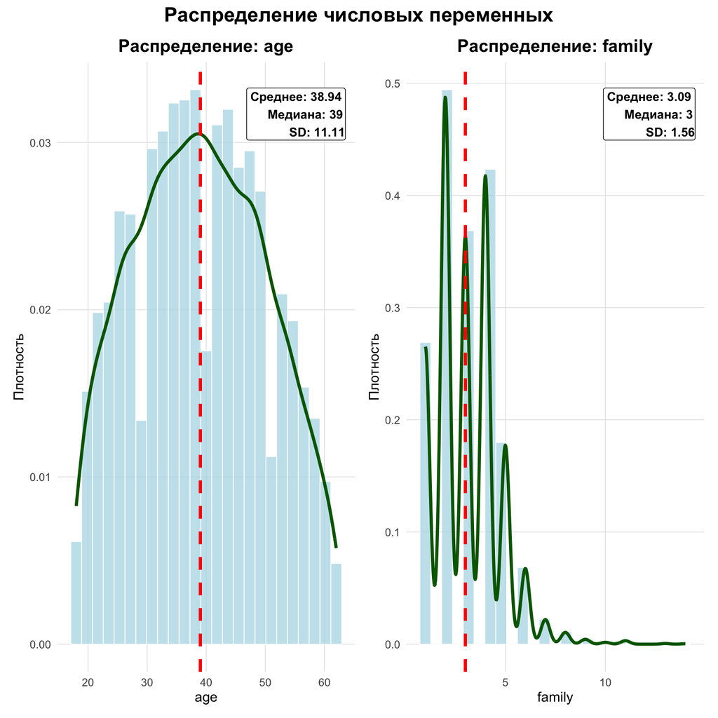

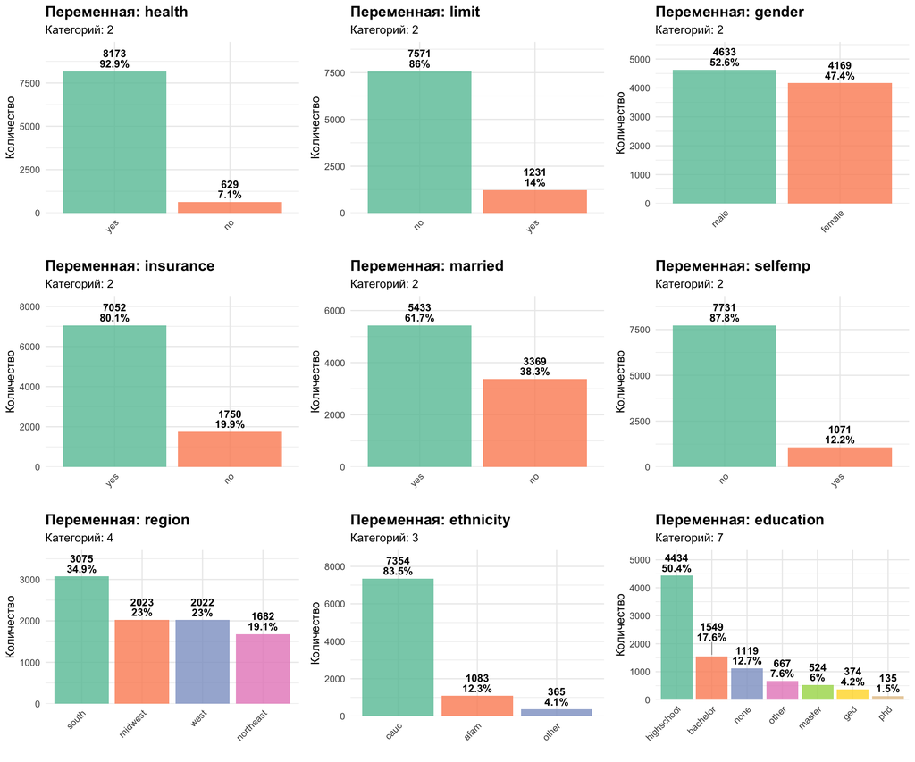

Поищем взаимосвязи с МС.

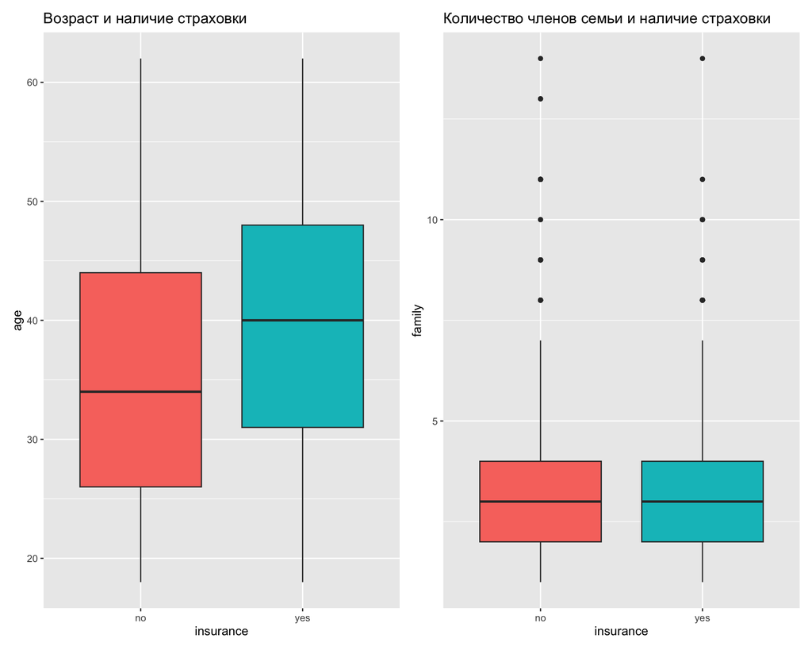

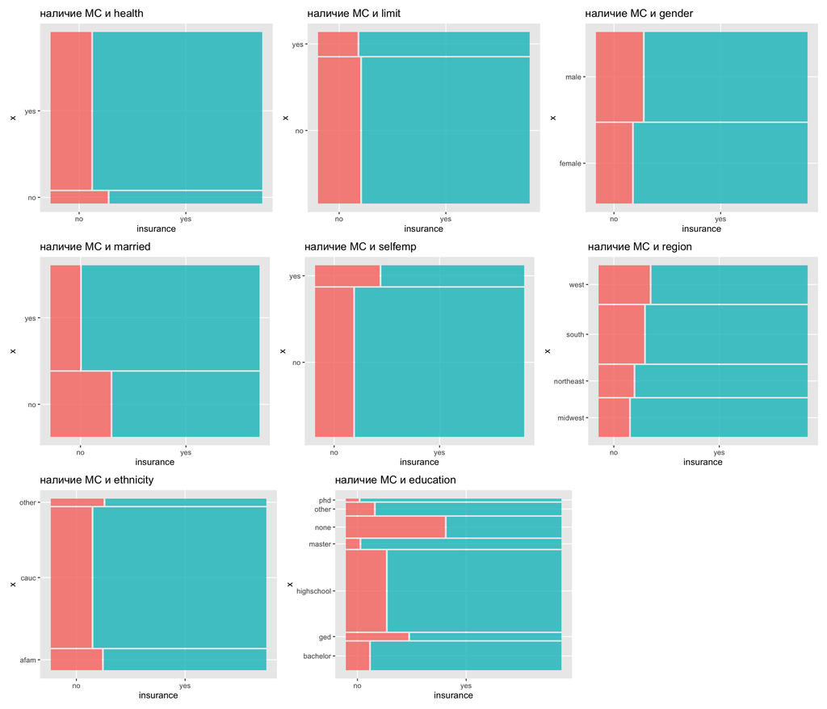

# Анализ данных

Выбрать и реализовать методы однофакторного анализа для количественной оценки взаимосвязи между наличием МС и собранными признаками пациентов (помните, что взаимосвязь - это не только p-значения, но и доверительные интервалы!).

Исследование кросс-секционное. Для оценки независимости групп с категориальными признаками будет использован тест хи-квадрат, для оценки силы ассоциации среди категориальных переменных будет использован RR.

Уровень значимости во всех случаях p<0.05

| Гендер и наличие страховки Пол | Гендер и наличие страховки Есть страховка | Гендер и наличие страховки Нет страховки |
| --- | --- | --- |
| female | 3,454 | 715 |
| male | 3,598 | 1,035 |

```
## Проверка гипотезы о независимости пола и наличия страховки
```

```
## [1] "Pearson's Chi-squared test with Yates' continuity correction"
```

```
## P-value:
```

```
## [1] 1.327252e-09
```

```
## Отклоняем нулевую гипотезу о независимости пола и наличия страховки
```

Сила ассоциации

```
##         risk ratio with 95% C.I.
## gender   estimate    lower    upper
##   male   1.000000       NA       NA
##   female 1.066821 1.044946 1.089155
```

```
## RR показывает, что у женщин есть страховка в 1.067 раз чаще CI (1.045 - 1.089)
```

## Семейное положение и страховка

| Семейное положение и наличие страховки Семейное положение | Семейное положение и наличие страховки Есть страховка | Семейное положение и наличие страховки Нет страховки |
| --- | --- | --- |
| В браке | 4,659 | 774 |
| Нет брака | 2,393 | 976 |

```
## Проверка гипотезы о независимости семейного положения и наличия страховки
```

```
## [1] "Pearson's Chi-squared test with Yates' continuity correction"
```

```
## P-value:
```

```
## [1] 2.630174e-63
```

```
## Отклоняем нулевую гипотезу о независимости семейного положения и наличия страховки
```

Сила ассоциации

```
##        risk ratio with 95% C.I.
## married estimate  lower    upper
##     no  1.000000     NA       NA
##     yes 1.207289 1.1785 1.236782
```

```
## RR показывает, что у людей в браке есть страховка в 1.2 раза чаще, CI(1.179 - 1.237)
```

## Самозанятость и страховка

| Самозанятость и наличие страховки Самозанятость | Самозанятость и наличие страховки Есть страховка | Самозанятость и наличие страховки Нет страховки |
| --- | --- | --- |
| Не самозанятый | 6,314 | 1,417 |
| Самозанятый | 738 | 333 |

```
## Проверка гипотезы о независимости статуса самозанятого и наличия страховки
```

```
## [1] "Pearson's Chi-squared test with Yates' continuity correction"
```

```
## P-value:
```

```
## [1] 1.5501e-22
```

```
## Отклоняем нулевую гипотезу о независимости статуса самозанятого и наличия страховки
```

Сила ассоциации

```
##        risk ratio with 95% C.I.
## selfemp  estimate     lower     upper
##     no  1.0000000        NA        NA
##     yes 0.8437193 0.8093466 0.8795518
```

```
## RR показывает, что у самозанятых есть страховка в 0.84 раз реже, CI(0.809 - 0.879)
```

```
##        risk ratio with 95% C.I.
## selfemp estimate    lower    upper
##     yes 1.000000       NA       NA
##     no  1.185228 1.136943 1.235565
```

```
## RR показывает, что у не самозанятых есть страховка в 1.19 раз чаще, CI(1.137 - 1.236)
```

## Здоровье и страховка

| Состояние здоровья и наличие страховки Состояние здоровья | Состояние здоровья и наличие страховки Есть страховка | Состояние здоровья и наличие страховки Нет страховки |
| --- | --- | --- |
| Болен | 458 | 171 |
| Здоров | 6,594 | 1,579 |

```
## Проверка гипотезы о независимости состояния здоровья и наличия страховки
```

```
## [1] "Pearson's Chi-squared test with Yates' continuity correction"
```

```
## P-value:
```

```
## [1] 2.460251e-06
```

```
## Отклоняем нулевую гипотезу о независимости состояния здоровья и наличия страховки
```

Сила ассоциации

[output not shown]

```
## RR показывает, что у здоровых есть страховка в 1.11 раза чаще, CI(1.055 - 1.164)
```

## Регион и страховка

| Регион проживания и наличие страховки Регион проживания | Регион проживания и наличие страховки Есть страховка | Регион проживания и наличие страховки Нет страховки |
| --- | --- | --- |
| midwest | 1,727 | 296 |
| northeast | 1,399 | 283 |
| south | 2,402 | 673 |
| west | 1,524 | 498 |

```
## Проверка гипотезы о независимости региона проживания и наличия страховки
```

```
## [1] "Pearson's Chi-squared test"
```

```
## P-value:
```

```
## [1] 1.668211e-17
```

```
## Отклоняем нулевую гипотезу о независимости региона проживания и наличия страховки
```

Сила ассоциации

```
##            risk ratio with 95% C.I.
## region       estimate     lower    upper
##   midwest   1.0000000        NA       NA
##   northeast 0.9743058 0.9473451 1.002034
```

```
## RR показывает, что у проживающих на северовостоке есть страховка в 0.974  раза реже, чем у тех, кто проживает на midwest CI(0.947 - 1.002)
##     CI накрывает 1!!!
```

```
##        risk ratio with 95% C.I.
## region   estimate     lower     upper
##   south 1.0000000        NA        NA
##   west  0.9648858 0.9352853 0.9954232
```

```
## RR показывает, что у проживающих на западе есть страховка в 0.964 раза реже, чем у тех, кто проживает на юге CI(0.935 - 0.995)
```

```
##          risk ratio with 95% C.I.
## region     estimate     lower    upper
##   midwest 1.0000000        NA       NA
##   south   0.9150218 0.8915467 0.939115
```

```
## RR показывает, что у проживающих на юге есть страховка в 0.915 раза реже, чем у тех, кто проживает на midwest CI(0.892 - 0.939)
```

```
##          risk ratio with 95% C.I.
## region     estimate     lower     upper
##   midwest 1.0000000        NA        NA
##   west    0.8828916 0.8561459 0.9104727
```

```
## RR показывает, что у проживающих на западе есть страховка в 0.883 раза реже, чем у тех, кто проживает на midwest CI(0.856 - 0.910)
```

```
##            risk ratio with 95% C.I.
## region       estimate     lower     upper
##   northeast 1.0000000        NA        NA
##   south     0.9391526 0.9127683 0.9662995
```

```
## RR показывает, что у проживающих на юге есть страховка в 0.939 раза реже, чем у тех, кто проживает на северовостоке CI(0.913 - 0.966)
```

```
##            risk ratio with 95% C.I.
## region      estimate     lower     upper
##   northeast 1.000000        NA        NA
##   west      0.906175 0.8768417 0.9364897
```

```
## RR показывает, что у проживающих на западе есть страховка в 0.906 раза реже, чем у тех, кто проживает на северовостоке CI(0.877 - 0.936)
```

## Образование и страховка

Образование можно представить как категориальную порядковую переменную, ведь PhD явно лучше bachelor. Можно попробовать применить тест Манна-Уитни Нулевая гипотеза: распределение уровней образования одинаково для обеих групп (со страховкой и без) Альтернативная гипотеза: распределение уровней образования различно для групп

```
## P-значение:
```

```
## [1] 3.906833e-70
```

```
## Отвергаем нулевую гипотезу об одинаковом распределении уровней образования для обеих групп
```

Другой вариант, категоризируем уровни образования на три категории и далее находим хи-квадрат и RR:

| Уровень образования и наличие страховки Уровень образования | Уровень образования и наличие страховки Есть страховка | Уровень образования и наличие страховки Нет страховки |
| --- | --- | --- |
| Отсутствие или другое | 1,181 | 605 |
| Школьный уровень | 3,871 | 937 |
| Высшее образование | 2,000 | 208 |

```
## Проверка гипотезы о независимости уровня образования и наличия страховки
```

```
## [1] "Pearson's Chi-squared test"
```

```
## P-value:
```

```
## [1] 1.927451e-81
```

```
## Отклоняем нулевую гипотезу о независимости уровня образования и наличия страховки
```

Сила ассоциаций

```
##                        risk ratio with 95% C.I.
## education               estimate   lower    upper
##   Отсутствие или другое  1.00000      NA       NA
##   Школьный уровень       1.21756 1.17452 1.262177
```

```
## RR показывает, что у людей со школьным уровнем образования в 1.2 раза чаще встречается страховка, чем у людей без образования или другое CI(1.17, 1.26)
```

```
##                        risk ratio with 95% C.I.
## education               estimate    lower    upper
##   Отсутствие или другое 1.000000       NA       NA
##   Высшее образование    1.369817 1.321624 1.419767
```

```
## RR показывает, что у людей с высшим образования в 1.37 раза чаще встречается страховка, чем у людей без образования или другое CI(1.32, 1.42)
```

```
##                     risk ratio with 95% C.I.
## education            estimate    lower   upper
##   Школьный уровень   1.000000       NA      NA
##   Высшее образование 1.125051 1.103493 1.14703
```

[output not shown]

## Этнос и страховка

```
## # A tibble: 3 × 2
##   ethnicity     n
##   <chr>     <int>
## 1 afam       1083
## 2 cauc       7354
## 3 other       365
```

| Этнос и наличие страховки Этнос | Этнос и наличие страховки Есть страховка | Этнос и наличие страховки Нет страховки |
| --- | --- | --- |
| afam | 824 | 259 |
| cauc | 5,953 | 1,401 |
| other | 275 | 90 |

```
## Проверка гипотезы о независимости этноса и наличия страховки
```

```
## [1] "Pearson's Chi-squared test"
```

```
## P-value:
```

```
## [1] 5.906316e-05
```

```
## Отклоняем нулевую гипотезу о независимости этноса и наличия страховки
```

Сила ассоциации

```
##          risk ratio with 95% C.I.
## ethnicity estimate   lower   upper
##      afam 1.000000      NA      NA
##      cauc 1.063931 1.02715 1.10203
```

```
## RR показывает, что у европеоидных людей в 1.06 раза чаще встречается страховка, чем у афроамериканцев CI(1.03, 1.10)
```

```
##          risk ratio with 95% C.I.
## ethnicity  estimate     lower    upper
##     afam  1.0000000        NA       NA
##     other 0.9902414 0.9255851 1.059414
```

```
## RR показывает, что у прочих людей в 0.99 раза реже встречается страховка, чем у афроамериканцев CI(0.926, 1.05)
##     CI наркывает 1!!!
```

```
##          risk ratio with 95% C.I.
## ethnicity  estimate     lower     upper
##     cauc  1.0000000        NA        NA
##     other 0.9307383 0.8767755 0.9880223
```

```
## RR показывает, что у прочих людей в 0.93 раза реже встречается страховка, чем у европеоидных CI(0.877, 0.988)
```

## Возраст и страховка

Возраст - количественная переменная. Для удобства можно разбить ее на 2 категории - до 40 лет и после.

| Возраст и наличие страховки Возраст | Возраст и наличие страховки Есть страховка | Возраст и наличие страховки Нет страховки |
| --- | --- | --- |
| Младше 40 | 3,697 | 1,183 |
| Старше 40 | 3,355 | 567 |

```
## Проверка гипотезы о независимости возраста и наличия страховки
```

```
## [1] "Pearson's Chi-squared test with Yates' continuity correction"
```

```
## P-value:
```

```
## [1] 3.926109e-30
```

```
## Отклоняем нулевую гипотезу о независимости возраста и наличия страховки
```

```
##            risk ratio with 95% C.I.
## age_binary  estimate    lower    upper
##   Младше 40  1.00000       NA       NA
##   Старше 40  1.12916 1.106324 1.152467
```

```
## RR показывает, что у людей старше 40 лет в 1.12 раз чаще встречается страховка CI(1.106324 - 1.152467)
```

## Число членов семьи и страховка

Предлагаю тоже поделить на категории, если в семье 1 человек, то он одиночка, если 2, то значит есть партнер, если больше, значит есть еще и дети.

| Семья и наличие страховки Возраст | Семья и наличие страховки Есть страховка | Семья и наличие страховки Нет страховки |
| --- | --- | --- |
| Есть дети | 4,093 | 1,071 |
| Есть партнер | 1,973 | 383 |
| Один | 986 | 296 |

```
## Проверка гипотезы о независимости семьи и наличия страховки
```

```
## [1] "Pearson's Chi-squared test"
```

```
## P-value:
```

```
## [1] 2.902805e-07
```

```
## Отклоняем нулевую гипотезу о независимости семьи и наличия страховки
```

```
##               risk ratio with 95% C.I.
## family_cat     estimate    lower    upper
##   Есть дети    1.000000       NA       NA
##   Есть партнер 1.056565 1.032945 1.080725
```

```
## RR показывает, что у тех у кого есть партнер в 1.06 раза чаще имеют страховку, чем те, у кого есть дети CI(1.03, 1.08)
```

```
##            risk ratio with 95% C.I.
## family_cat   estimate    lower    upper
##   Есть дети 1.0000000       NA       NA
##   Один      0.9703611 0.938788 1.002996
```

```
## RR показывает, что те, кто один в 0.97 раза реже имеют страховку, чем те, у кого есть дети CI(0.938788 1.002996)
##     CI накрывает 1!!!
```

```
##               risk ratio with 95% C.I.
## family_cat     estimate     lower     upper
##   Есть партнер 1.000000        NA        NA
##   Один         0.918411 0.8869362 0.9510029
```

```
## RR показывает, что те, кто один в 0.91 раза реже имеют страховку, чем те, у кого есть партнер CI(0.8869362 0.9510029)
```

# Визуализация результатов

[figure not shown]

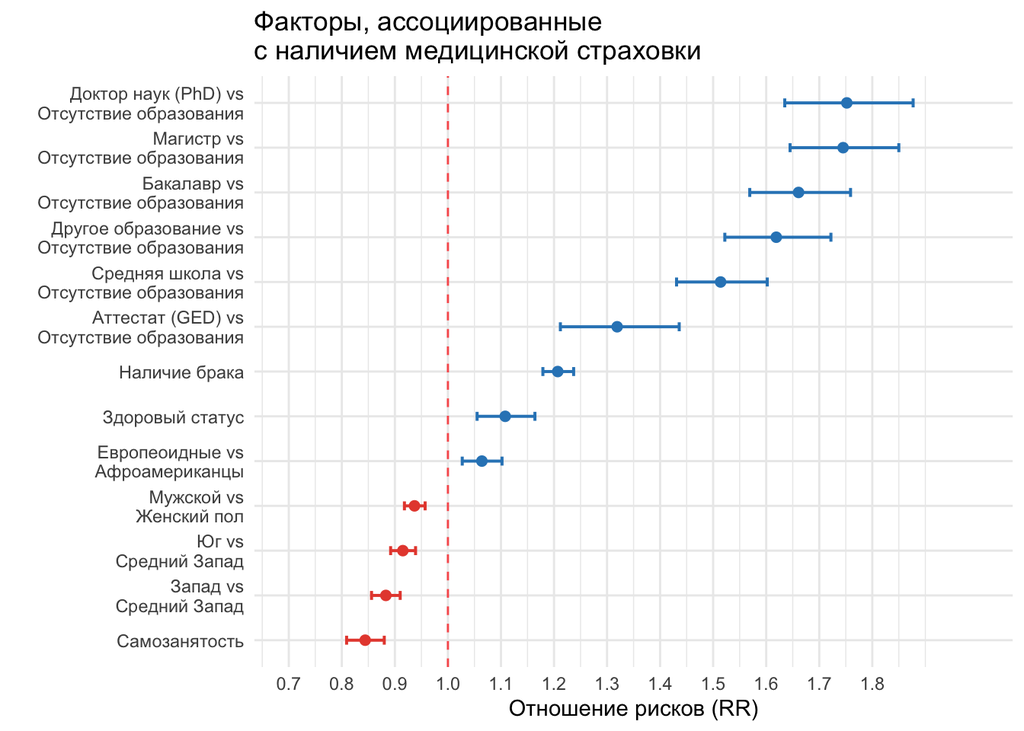

Итого получилось, что Женщины чаще имеют страховку в 1.067 раз CI (1.045 - 1.089) У людей в браке есть страховка в 1.2 раза чаще, CI(1.179 - 1.237) У самозанятых есть страховка в 0.84 раз реже, CI(0.809 - 0.879) У здоровых есть страховка в 1.11 раза чаще, CI(1.055 - 1.164)

Регион проживания: У проживающих на северовостоке есть страховка в 0.974 раза реже, чем у тех, кто проживает на midwest CI(0.947 - 1.002) У проживающих на западе есть страховка в 0.964 раза реже, чем у тех, кто проживает на юге CI(0.935 - 0.995) у проживающих на юге есть страховка в 0.915 раза реже, чем у тех, кто проживает на midwest CI(0.892 - 0.939) у проживающих на западе есть страховка в 0.883 раза реже, чем у тех, кто проживает на midwest CI(0.856 - 0.910) у проживающих на юге есть страховка в 0.939 раза реже, чем у тех, кто проживает на северовостоке CI(0.913 - 0.966) у проживающих на западе есть страховка в 0.906 раза реже, чем у тех, кто проживает на северовостоке CI(0.877 - 0.936) То есть страховка встречается чаще всего у людей с северовостока и midwest

Этнос у европеоидных людей в 1.06 раза чаще встречается страховка, чем у афроамериканцев CI(1.03, 1.10) у прочих людей в 0.99 раза реже встречается страховка, чем у афроамериканцев CI(0.926, 1.05) у прочих людей в 0.93 раза реже встречается страховка, чем у европеоидных CI(0.877, 0.988) То есть сильнее связь с европеоидными людьми.

Возраст у людей старше 40 лет в 1.12 раз чаще встречается страховка CI(1.106324 - 1.152467)

Семья у тех у кого есть партнер в 1.06 раза чаще имеют страховку, чем те, у кого есть дети CI(1.03, 1.08) те, кто один в 0.97 раза реже имеют страховку, чем те, у кого есть дети CI(0.938788 1.002996) те, кто один в 0.91 раза реже имеют страховку, чем те, у кого есть партнер CI(0.8869362 0.9510029)” То есть сильнее связь в тех ситуациях, когда в семье 2 человека.

# Результаты

3. РЕЗУЛЬТАТЫ

3.1. Описательная статистика В исследовании приняли участие 8802 респондента. Описательные характеристики всей выборки, а также отдельно групп лиц с медицинской страховкой и без нее, представлены в Таблице 1.

Анализ таблицы выявил систематические различия между группами. Респонденты без страховки были в среднем моложе и реже состояли в браке. Среди незастрахованных была выше доля мужчин, самозанятых, а также представителей афроамериканской и других этнических групп.

Образовательный профиль также различался: среди лиц без страховки преобладали респонденты без диплома и со средним образованием, тогда как среди застрахованных была выше доля лиц с высшим образованием.

Что касается здоровья, респонденты без страховки реже оценивали свое здоровье как хорошее, однако наличие физических ограничений было сопоставимым между группами.

4. ОБСУЖДЕНИЕ

Проведенный анализ выявил комплекс факторов, значимо ассоциированных с наличием медицинской страховки у респондентов. Ключевыми детерминантами оказались социально-экономические характеристики, в первую очередь — уровень образования и статус занятости.

Связь с высшим образованием можно объяснить тем, что более высокий уровень образования связан с выходом на рынок труда, где работодатели предоставляют групповые страховки, а также с большей осведомленностью о важности страхования и финансовой возможностью его приобрести.

5. ВЫВОД

Проведенное исследование позволило идентифицировать ключевые социально-демографические и экономические детерминанты, ассоциированные с наличием медицинской страховки в США. Установлено, что вероятность наличия страхового покрытия ассоциирована с уровнем образования, семейным положением, статусом занятости, полом, этнической принадлежностью и регионом проживания.